# Evolution

Research Cluster 1

“Evolution” captures a recurring question across Cluster 1: how did stars, living populations, and geological formations come to be, and what processes changed them over time? Community 1 brings together stellar and biological evolution. In astronomy, researchers model how clouds of gas collapse, how young stars gather material, and how stars develop. The biological strand includes research on sexual reproduction, particularly how mate preferences and differences in body size between the sexes relate to mating success. These are questions about sexual selection and how traits associated with mating success can become more common over generations. Kinship, relatedness, and gene flow point to a related interest in how populations are structured and how genetic variation moves among them. A separate community uses DNA and plant traits to reconstruct how grass lineages arose and diverged and to inform their classification.

Seven of the cluster’s ten communities examine geological change, from the formation of individual rocks and mineral deposits to the movement and assembly of continents. The volcanic-rock geochemistry community uses the composition of rocks to infer where magmas came from and how they changed. The mineralization community examines how crystallization and the movement of hot fluids concentrate elements and form deposits. Research on the North Mountain Basalt follows volcanic activity and the emplacement of lava flows during rifting around the Bay of Fundy, alongside work on sediment deposition in coastal settings.

The other geological communities reconstruct change at the scale of basins and regions. In the Maritimes and northern Appalachians, researchers use rock ages and composition to study how blocks of crust came together and how basins filled. Offshore Nova Scotia, they trace where sediments came from, how they accumulated, and how burial, heat, and fluids changed them. In southern Mexico, rock ages and deformation help reconstruct ancient plate boundaries and the former positions of continents and oceans. In northwest China, rocks and sediments record how continental crust grew, how basins developed, and how past environments changed.

Corporate finance forms a distinct strand within the cluster. It examines how access to cash, borrowing, and conflicts of interest within firms relate to investment decisions and how efficiently firms allocate capital.

Three forms of evidence below show what the keyword communities are about and how they relate to one another.

**Interactive keyword network.** Each point represents a keyword, and a line connects two keywords that appear together in one or more publications. The full network shows how keyword communities relate to one another. Select a community from the dropdown to see which terms group together and which connect to terms in other communities. Connections within a community show which subjects, methods, or concepts appear together. Connections across communities show where their vocabularies overlap.

**Community word clouds.** Each cloud shows the vocabulary of one community. Larger words have higher within-community PageRank. This measure reflects both the strength of a keyword’s connections and how well connected its neighbours are. Larger words therefore show which terms are most prominent in the community’s pattern of connections. Smaller words can give those terms context by identifying particular subjects, settings, or methods.

**Affiliated publications.** Each publication has a set of membership values, one for each community. A value of 1 means that all of the publication’s keyword-based membership is assigned to that community. When membership is distributed across communities, the values show how that affiliation is shared. For example, values of 0.7 and 0.3 indicate that the publication’s keywords align more strongly with the first community while also connecting it to the second. The publication lists show how the themes visible in the keyword network are represented in the institution’s research.

[interactive chart not shown]

## Community 1: Stellar formation and evolution; sexual selection and population structure

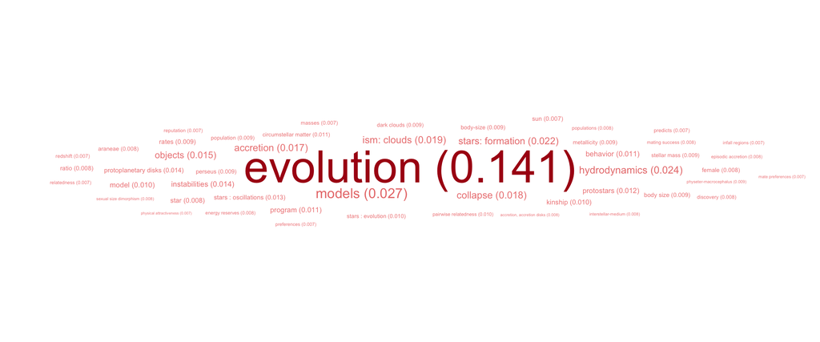

Community 1 of Cluster 1 centres on how stars form and evolve. “Evolution” has the highest within-community PageRank (0.141), more than five times that of “models” (0.027), the next-ranked term. “Hydrodynamics,” “stars: formation,” “collapse,” and “accretion” point to research that models how interstellar clouds collapse and how young stars gather material. Protoplanetary disks connect this work to the formation of planetary systems, while stellar oscillations point to how researchers probe the internal structure of stars.

The community also contains a strand in which evolution takes on a biological meaning. “Kinship,” “pairwise relatedness,” and “gene flow” point to research on how populations are structured. “Sexual size dimorphism,” “mating success,” and “mate preferences” point to research on sexual selection. In this community, “evolution” names two kinds of inquiry, with the highest-ranking subject terms giving the community its focus on stars.

## Community 2: Volcanic rock geochemistry

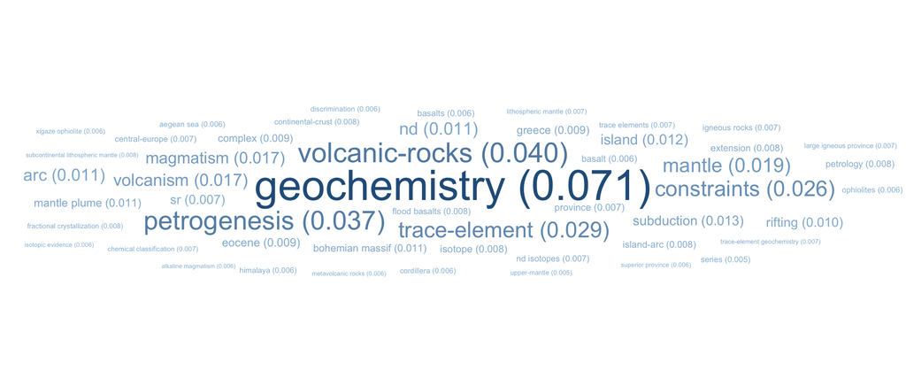

Community 2 of Cluster 1 focuses on where magmas come from and how they change before forming volcanic rocks. “Geochemistry” has the highest within-community PageRank (0.071), followed by “volcanic rocks” (0.040) and “petrogenesis” (0.037), the study of how rocks form. Trace elements and isotopes of neodymium and strontium provide clues to a magma’s source. Terms such as “fractional crystallization,” “magma mixing,” and “crustal contamination” point to ways its composition can change as minerals crystallize, magmas mix, or magma interacts with the surrounding crust. Subduction zones, continental rifts, and mantle plumes give these questions different tectonic settings.

Like the star formation community, this community asks how the objects it studies came to be. Community 1 uses observations and models to investigate how stars form and evolve. Here, the chemical composition of rocks provides evidence about the sources and histories of the magmas that formed them.

## Community 3: Maritime and nothern Appalachian geology

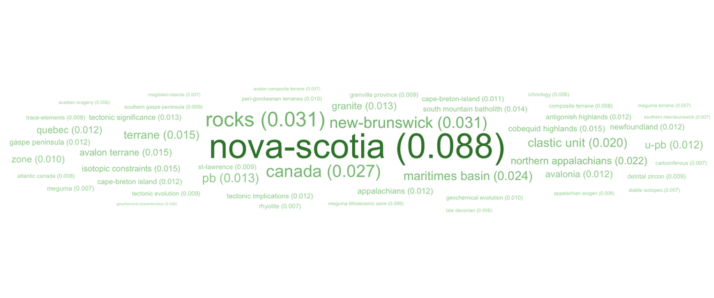

Community 3 of Cluster 1 reconstructs the geological history of Atlantic Canada and the northern Appalachians. “Nova Scotia” has the highest within-community PageRank (0.088), followed by “New Brunswick” (0.031), “rocks” (0.031), and “Canada” (0.027). The geological terms give that regional focus more detail. “Maritimes Basin” and “clastic unit” point to work on sedimentary deposits and how basins filled. “Avalonia,” “Meguma,” and “Ganderia” point to questions about how blocks of crust with distinct geological histories came together. Uranium–lead dating and other isotope analyses help establish when events occurred and where rock or sediment came from.

The closest connection is to Community 2’s work on volcanic-rock geochemistry. Both use the chemical and isotopic record in rocks to reconstruct past events. Community 2 emphasizes where magmas came from and how they changed across tectonic settings. Community 3 uses some of the same evidence, alongside sedimentary records and rock ages, to explain how a region took shape.

## Community 4: Molecular evolution and classification of plants, centred on grasses

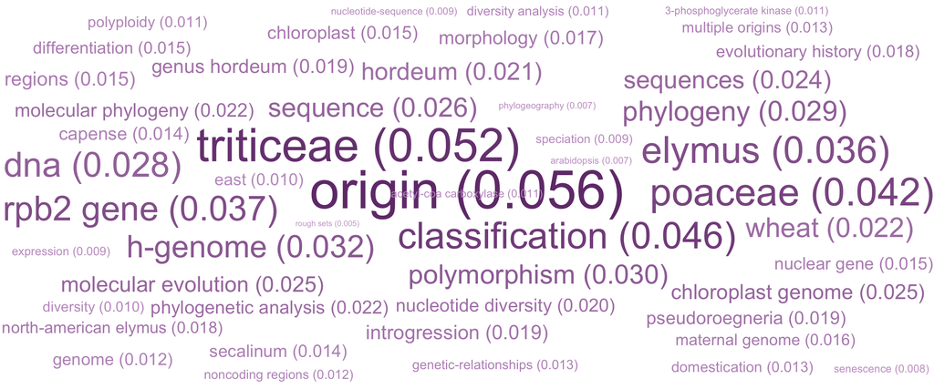

Community 4 of Cluster 1 examines how plant lineages arose and how their evolutionary relationships inform classification. “Origin” has the highest within-community PageRank (0.056), followed by “Triticeae” (0.052), “classification” (0.046), and “Poaceae” (0.042). These terms place the focus within the grass family, particularly the tribe that includes wheat, barley, and *Elymus*. “RPB2 gene,” “chloroplast genome,” and “morphology” point to the kinds of evidence researchers compare to reconstruct ancestry. “Introgression,” “polyploidy,” and “multiple origins” suggest why those histories can be difficult to untangle: lineages can exchange genetic material through interbreeding, and similar forms can arise more than once. *Arabidopsis* also appears, extending the plant research beyond grasses.

This community connects most directly to the biological strand of Community 1. There, kinship and gene flow point to how populations are structured, while mating success and mate preferences point to sexual selection. Here, the emphasis is on how plant lineages arose and how to classify them. The connection to the geological communities is in the use of present-day evidence to reconstruct origins, with genes and plant traits providing a different kind of record from rock chemistry and isotopes.

## Community 5: Sediment provenance and offshore basin history

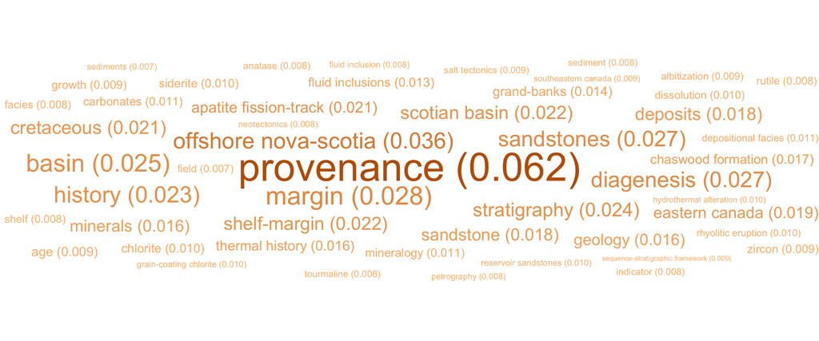

Community 5 of Cluster 1 examines where sediments came from, how they accumulated, and how they changed after deposition along the eastern Canadian continental margin. “Provenance” has the highest within-community PageRank (0.062), followed by “offshore Nova Scotia” (0.036) and “margin” (0.028). The Scotian Basin and the Grand Banks give the work a regional focus. Minerals such as zircon and detrital muscovite provide clues to the source rocks, while stratigraphy helps reconstruct the sequence in which sediments accumulated. “Diagenesis,” “thermal history,” and “fluid inclusions” point to a further question about how burial, heating, and fluid movement altered the resulting rocks.

This community extends Community 3’s work on the geological history of Atlantic Canada offshore, with a more specific focus on sedimentary basins. It also shares Community 2’s interest in reconstructing origins from rocks. In the volcanic-rock community, the question is where magmas came from and how they changed. Here, it is where sediment grains came from and what those grains and the rocks they form can tell us about a basin’s history.

## Community 6: Southern Mexico and the reconstruction of ancient plate boundaries

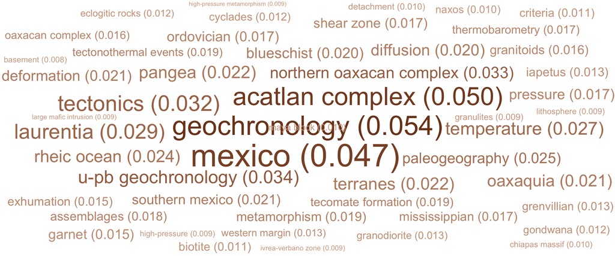

Community 6 of Cluster 1 examines what the rocks of southern Mexico reveal about the former positions of continents and oceans. “Geochronology” (0.054), “Acatlán Complex” (0.050), and “Mexico” (0.047) have the highest within-community PageRank. The Acatlán and Oaxacan complexes anchor the work in southern Mexico, while “Laurentia,” “Gondwana,” “Rheic Ocean,” and “Pangea” point to questions about where blocks of crust once lay and how they came together. Uranium–lead dating helps establish when events occurred. Minerals in rocks such as blueschist and eclogite record the pressure and temperature conditions the rocks experienced, while deformation and exhumation point to how they moved through the crust and returned toward the surface.

The closest parallel is Community 3, which also uses rock ages and relationships among blocks of crust to reconstruct regional tectonic history. There, the focus is on Atlantic Canada and the northern Appalachians. Here, the rock record of southern Mexico helps place that region in the larger history of ancient ocean basins and continental assembly. Community 5 also reconstructs a regional history from rocks, with sediment sources and burial as its focus.

## Community 7: Igneous activity and mineral deposit formaiton

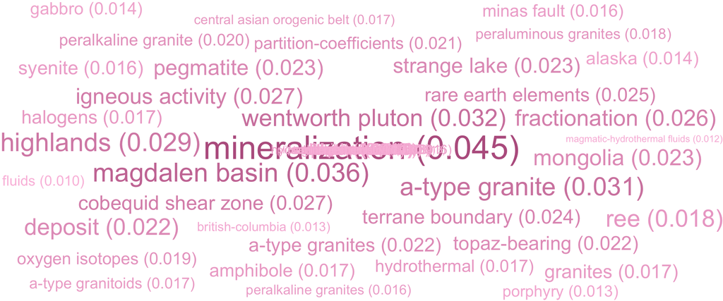

Community 7 of Cluster 1 examines how magmas and hot fluids concentrate elements and form mineral deposits. “Mineralization” has the highest within-community PageRank (0.045), followed by “Magdalen Basin” (0.036), “Wentworth Pluton” (0.032), and “A-type granite” (0.031). The Magdalen Basin, Wentworth Pluton, and Cobequid Shear Zone connect this community to Community 3’s work on the geological history of Atlantic Canada. Here, those regional terms appear alongside questions about how igneous activity and fluid movement contribute to mineralization. “Rare earth elements,” “lithium,” and “gold deposit” indicate the range of elements and deposits under study.

The community also overlaps with Community 2’s work on how magmas change as minerals crystallize. In Community 2, that process helps explain the composition of volcanic rocks. Here, the emphasis is on how crystallization and the movement of hot fluids can concentrate elements. Keywords such as “Strange Lake,” “British Columbia,” and “porphyry” extend that inquiry beyond the Maritime setting.

## Community 8: North Mountain Basalt and Bay of Fundy geology

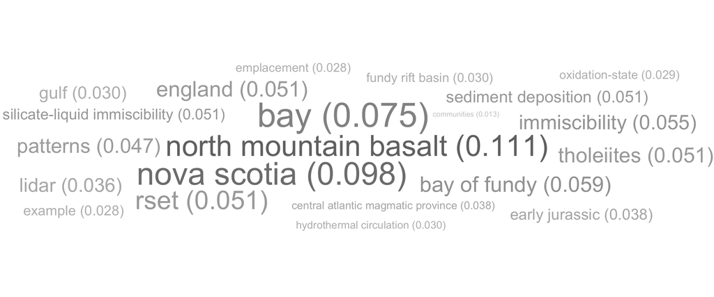

Community 8 of Cluster 1 centres on the North Mountain Basalt and the geology of the Bay of Fundy. “North Mountain Basalt” has the highest within-community PageRank (0.111), followed by “Nova Scotia” (0.098), “bay” (0.075), and “Bay of Fundy” (0.059). “Early Jurassic,” “Fundy Rift Basin,” and “Central Atlantic Magmatic Province” place the basalt in the history of rifting and volcanism. “Emplacement” points to how the lava flows came to occupy their present setting, while “silicate-liquid immiscibility” points to how a magma can separate into two liquids as it evolves. “Sediment deposition” and “LiDAR” also suggest work on coastal processes and how they are measured.

The community narrows Community 3’s regional focus to a particular rock formation and its setting. It also gives Community 2’s work on volcanic-rock geochemistry a local counterpart, with the North Mountain Basalt providing a case for studying how magma evolved and was emplaced. The sediment terms overlap with Community 5’s interest in deposition, where the emphasis is on sediment sources and the history of offshore basins.

## Community 9: Continental growth and basin history of northwest China

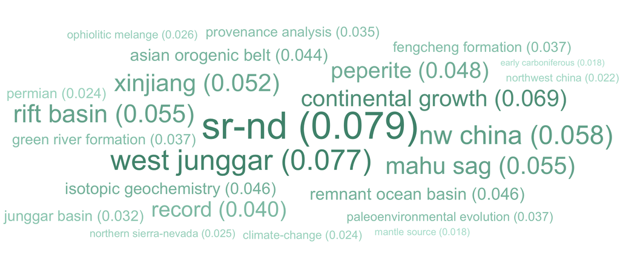

Community 9 of Cluster 1 examines how continental crust grew and how sedimentary basins developed in northwest China. “Sr–Nd” (0.079), “West Junggar” (0.077), and “continental growth” (0.069) lead the within-community PageRank ranking. Strontium and neodymium isotopes help researchers infer where rocks and magmas came from, while “remnant ocean basin” and “ophiolitic mélange” point to the use of preserved oceanic rocks to reconstruct the region’s tectonic history. A second strand focuses on the Junggar Basin. “Mahu Sag,” “rift basin,” and “Fengcheng Formation” identify settings for research on how the basin formed, where its sediments came from, and what those deposits record about past environments.

The tectonic strand parallels Community 6’s reconstruction of ancient oceans and continental assembly in southern Mexico. It also shares methods with Community 2, where isotope evidence helps explain the origins of volcanic rocks. The sedimentary strand is closer to Community 5’s work offshore Atlantic Canada. Both use sediment sources to reconstruct basin history, with the Junggar keywords giving more attention to past depositional environments and the offshore Atlantic keywords giving more attention to what happened to sediments after burial.

## Community 10: Corporate finance and investment efficiency

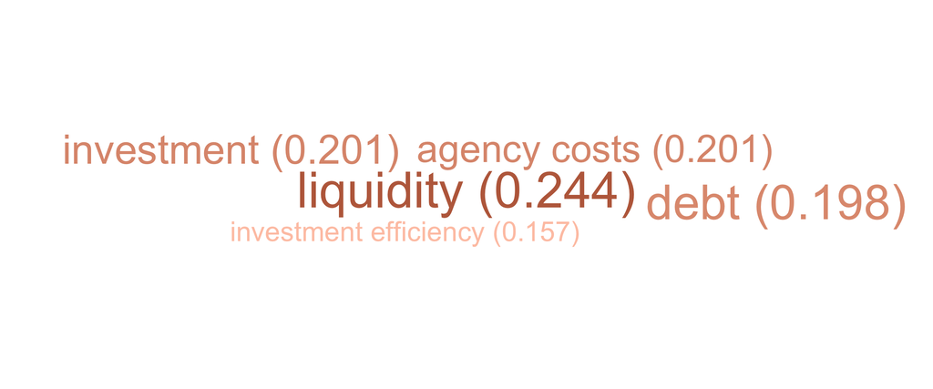

Community 10 of Cluster 1 concerns how firms finance their investments and how well they allocate capital. “Liquidity” has the highest within-community PageRank (0.244), followed by “agency costs” and “investment” (both 0.201), and “debt” (0.198). Read together, these terms suggest questions about how access to cash, borrowing, and conflicts of interest within firms relate to investment decisions. The closest thematic parallel is the corporate governance and firm performance community in Cluster 2, which also includes agency costs and investment. Within Cluster 1, this community represents a distinct line of corporate finance research alongside the work on geological, stellar, and biological origins.

## Most cited publications by community

Select one of the communities above to populate the table. The table shows up to five publications per selected research community, arranged by highest Total Citation count within the research community under consideration. Under Membership vector the column headers indicate abbreviated research community labels. Each row sum totals 1.0. Values of 1 indicate maximal research community affiliation; distributed values indicate multithematic papers whose affiliation reaches into more than one research community (Aria et al. 2026; Aria and Cuccurullo 2026). TCpY = Total Citations per Year.

Community:

| Publication title | Year | TC | TCpY | Membership vector Ste. | Membership vector Vol. | Membership vector Mar. | Membership vector Mol. | Membership vector Sed. | Membership vector Sou. | Membership vector Ign. | Membership vector Nor. | Membership vector Con. | Membership vector Cor. |
| --- | --- | --- | --- | --- | --- | --- | --- | --- | --- | --- | --- | --- | --- |
| Transcription Factors and their Genes in Higher Plants - Functional Domains, Evolution and Regulation | 1999 | 379 | 13.5 | 1.0 | 0.0 | 0.0 | 0.0 | 0.0 | 0.0 | 0.0 | 0.0 | 0.0 | 0.0 |
| Related: An r Package for Analysing Pairwise Relatedness from Codominant Molecular Markers | 2015 | 345 | 28.8 | 1.0 | 0.0 | 0.0 | 0.0 | 0.0 | 0.0 | 0.0 | 0.0 | 0.0 | 0.0 |
| The Burst Mode of Accretion and Disk Fragmentation in the Early Embedded Stages of Star Formation | 2010 | 247 | 14.5 | 1.0 | 0.0 | 0.0 | 0.0 | 0.0 | 0.0 | 0.0 | 0.0 | 0.0 | 0.0 |
| a Massive Core for a Cluster of Galaxies at a Redshift of 4.3 | 2018 | 189 | 21.0 | 1.0 | 0.0 | 0.0 | 0.0 | 0.0 | 0.0 | 0.0 | 0.0 | 0.0 | 0.0 |
| Neptune's Migration into a Stirred-Up Kuiper Belt: a Detailed Comparison of Simulations to Observations | 2005 | 173 | 7.9 | 0.9 | 0.0 | 0.0 | 0.1 | 0.0 | 0.0 | 0.0 | 0.0 | 0.0 | 0.0 |
| Zr/Hf Fractionation in Intraplate Basaltic Rocks - Carbonate Metasomatism in the Mantle Source | 1992 | 262 | 7.5 | 0.0 | 0.9 | 0.0 | 0.1 | 0.0 | 0.0 | 0.0 | 0.0 | 0.0 | 0.0 |
| Petrology and Geochemistry of the Saga and Sangsang Ophiolitic Massifs, Yarlung Zangbo Suture Zone, Southern Tibet: Evidence for an Arc-Back-Arc Origin | 2009 | 168 | 9.3 | 0.1 | 0.9 | 0.0 | 0.0 | 0.0 | 0.1 | 0.0 | 0.0 | 0.0 | 0.0 |
| Carbonate Metasomatism in the Lithospheric Mantle - Peridotitic Xenoliths from a Melilititic District of the Sahara Basin | 1992 | 160 | 4.6 | 0.1 | 0.9 | 0.0 | 0.0 | 0.0 | 0.0 | 0.0 | 0.0 | 0.0 | 0.0 |
| Recurrent Cenozoic Volcanic Activity in the Bohemian Massif (Czech Republic) | 2011 | 154 | 9.6 | 0.1 | 0.9 | 0.0 | 0.0 | 0.0 | 0.0 | 0.0 | 0.0 | 0.0 | 0.0 |
| Petrological and Geochemical Evidence for the Origin of the Yarlung Zangbo Ophiolites, Southern Tibet | 2005 | 154 | 7.0 | 0.1 | 0.7 | 0.1 | 0.0 | 0.0 | 0.0 | 0.1 | 0.0 | 0.0 | 0.0 |
| Tethyan, Mediterranean, and Pacific Analogues for the Neoproterozoic-Paleozoic Birth and Development of Peri-Gondwanan Terranes and their Transfer to Laurentia and Laurussia | 2003 | 174 | 7.2 | 0.0 | 0.0 | 0.8 | 0.0 | 0.0 | 0.2 | 0.0 | 0.0 | 0.0 | 0.0 |
| Origin of Topaz-Bearing and Related Peraluminous Granites of the Late Devonian Davis Lake Pluton, Nova-Scotia, Canada - Crystal Versus Fluid Fractionation | 1995 | 93 | 2.9 | 0.2 | 0.0 | 0.8 | 0.0 | 0.0 | 0.0 | 0.0 | 0.0 | 0.0 | 0.0 |
| Chronology of Devonian to Early Carboniferous Rifting and Igneous Activity in Southern Magdalen Basin Based on u-Pb (Zircon) Dating | 2002 | 78 | 3.1 | 0.0 | 0.1 | 0.9 | 0.0 | 0.0 | 0.0 | 0.0 | 0.0 | 0.0 | 0.0 |
| Geochemical Evolution of Devonian-Carboniferous Igneous Rocks of the Magdalen Basin, Eastern Canada: Pb- and Nd-Isotope Evidence for Mantle and Lower Crustal Sources | 1998 | 75 | 2.6 | 0.0 | 0.2 | 0.8 | 0.0 | 0.0 | 0.0 | 0.0 | 0.0 | 0.0 | 0.0 |
| Deep Seismic-Reflection Data from the Bay of Fundy and Gulf of Maine -Tectonic Implications for the Northern Appalachians | 1991 | 74 | 2.1 | 0.0 | 0.2 | 0.7 | 0.0 | 0.1 | 0.0 | 0.0 | 0.0 | 0.0 | 0.0 |
| Evolution and Association Analysis of Gmcyp78a10 Gene with Seed Size/Weight and Pod Number in Soybean | 2015 | 82 | 6.8 | 0.3 | 0.0 | 0.0 | 0.7 | 0.0 | 0.0 | 0.0 | 0.0 | 0.0 | 0.0 |
| Unsupervised Rough Set Classification using Gas | 2001 | 62 | 2.4 | 0.0 | 0.0 | 0.0 | 1.0 | 0.0 | 0.0 | 0.0 | 0.0 | 0.0 | 0.0 |
| Geomorphological Signatures: Classification of Aggregated Slope Unit Objects from Digital Elevation and Remote Sensing Data | 1998 | 49 | 1.7 | 0.5 | 0.0 | 0.0 | 0.5 | 0.0 | 0.0 | 0.0 | 0.0 | 0.0 | 0.0 |
| Early Diagenetic Origin of Al Phosphate-Sulfate Minerals (Woodhouseite and Crandallite Series) in Terrestrial Sandstones, Nova Scotia, Canada | 2005 | 32 | 1.5 | 0.0 | 0.0 | 0.0 | 1.0 | 0.0 | 0.0 | 0.0 | 0.0 | 0.0 | 0.0 |
| Tibet as a Potential Domestication Center of Cultivated Barley of China | 2013 | 30 | 2.1 | 0.4 | 0.0 | 0.0 | 0.6 | 0.0 | 0.0 | 0.0 | 0.0 | 0.0 | 0.0 |
| Geochemical Identification of Clastic Sediment Provenance from Known Sources of Similar Geology: The Cretaceous Scotian Basin, Canada | 2008 | 113 | 5.9 | 0.0 | 0.0 | 0.2 | 0.0 | 0.8 | 0.0 | 0.0 | 0.0 | 0.0 | 0.0 |
| Relationship of Diagenetic Chlorite Rims to Depositional Facies in Lower Cretaceous Reservoir Sandstones of the Scotian Basin | 2010 | 98 | 5.8 | 0.0 | 0.0 | 0.0 | 0.1 | 0.9 | 0.0 | 0.0 | 0.0 | 0.0 | 0.0 |
| Actor-Network Theory, Anti-History and Critical Organizational Historiography | 2012 | 94 | 6.3 | 0.0 | 0.0 | 0.0 | 0.0 | 1.0 | 0.0 | 0.0 | 0.0 | 0.0 | 0.0 |
| Controls on Diagenesis of Lower Cretaceous Reservoir Sandstones in the Western Sable Subbasin, Offshore Nova Scotia | 2010 | 87 | 5.1 | 0.1 | 0.0 | 0.0 | 0.1 | 0.9 | 0.0 | 0.0 | 0.0 | 0.0 | 0.0 |
| Sediment Geochemistry as a Provenance Indicator: Unravelling the Cryptic Signatures of Polycyclic Sources, Climate Change, Tectonism and Volcanism | 2014 | 68 | 5.2 | 0.0 | 0.3 | 0.0 | 0.0 | 0.7 | 0.0 | 0.0 | 0.0 | 0.0 | 0.0 |
| Geochronology and Geochemistry of Grenvillian Igneous Suites in the Northern Oaxacan Complex, Southern Mexico: Tectonic Implications | 2003 | 169 | 7.0 | 0.0 | 0.3 | 0.0 | 0.0 | 0.0 | 0.7 | 0.0 | 0.0 | 0.0 | 0.0 |
| Synthesis and Tectonic Interpretation of the Westernmost Paleozoic Variscan Orogen in Southern Mexico: From Rifted Rheic Margin to Active Pacific Margin | 2008 | 120 | 6.3 | 0.1 | 0.1 | 0.0 | 0.0 | 0.1 | 0.7 | 0.0 | 0.0 | 0.1 | 0.0 |
| Comparative Evolution of the Iapetus and Rheic Oceans: a North America Perspective | 2010 | 86 | 5.1 | 0.0 | 0.2 | 0.2 | 0.0 | 0.0 | 0.6 | 0.0 | 0.0 | 0.0 | 0.0 |
| Regional Implications of Geochemistry and Style of Emplacement of Miocene i-Type Diorite and Granite, Delos, Cyclades, Greece | 2002 | 78 | 3.1 | 0.1 | 0.2 | 0.1 | 0.0 | 0.1 | 0.6 | 0.0 | 0.0 | 0.0 | 0.0 |
| Ordovician-Earliest Silurian Rift Tholeiites in the Acatlan Complex, Southern Mexico: Evidence of Rifting on the Southern Margin of the Rheic Ocean | 2008 | 65 | 3.4 | 0.0 | 0.2 | 0.1 | 0.0 | 0.0 | 0.7 | 0.0 | 0.0 | 0.0 | 0.0 |
| Cretaceous Ongonites (Topaz-Bearing Albite-Rich Microleucogranites) from Ongon Khairkhan, Central Mongolia: Products of Extreme Magmatic Fractionation and Pervasive Metasomatic Fluid: Rock Interaction | 2015 | 148 | 12.3 | 0.0 | 0.1 | 0.1 | 0.0 | 0.0 | 0.0 | 0.8 | 0.0 | 0.0 | 0.0 |
| Trace Element Geochemistry of Scheelite and Rutile from Metaturbidite-Hosted Quartz Vein Gold Deposits, Meguma Terrane, Nova Scotia, Canada: Genetic Implications | 2009 | 112 | 6.2 | 0.0 | 0.2 | 0.1 | 0.1 | 0.0 | 0.0 | 0.6 | 0.0 | 0.0 | 0.0 |
| The Early Jurassic Bokan Mountain Peralkaline Granitic Complex (Southeastern Alaska): Geochemistry, Petrogenesis and Rare-Metal Mineralization | 2014 | 83 | 6.4 | 0.0 | 0.1 | 0.1 | 0.0 | 0.0 | 0.0 | 0.8 | 0.0 | 0.0 | 0.0 |
| Geochemical Variation of Amphiboles in a-Type Granites as an Indicator of Complex Magmatic Systems: Wentworth Pluton, Nova Scotia, Canada | 2014 | 35 | 2.7 | 0.1 | 0.1 | 0.1 | 0.0 | 0.0 | 0.1 | 0.7 | 0.0 | 0.0 | 0.0 |
| Early Carboniferous Deformation and Mineralization in the Cobequid Shear Zone, Nova Scotia: An 40ar/39ar Geochronology Study | 2004 | 35 | 1.5 | 0.1 | 0.0 | 0.1 | 0.0 | 0.0 | 0.1 | 0.7 | 0.0 | 0.0 | 0.0 |
| Ecological Re-Engineering of a Freshwater Impoundment for Salt Marsh Restoration in a Hypertidal System | 2010 | 36 | 2.1 | 0.1 | 0.0 | 0.0 | 0.0 | 0.0 | 0.0 | 0.0 | 0.9 | 0.0 | 0.0 |
| Macro-Tidal Salt Marsh Ecosystem Response to Culvert Expansion | 2011 | 30 | 1.9 | 0.1 | 0.0 | 0.0 | 0.0 | 0.0 | 0.0 | 0.0 | 0.9 | 0.0 | 0.0 |
| Late-Stage Crystallization History of the Jurassic North Mountain Basalt, Nova Scotia, Canada. I. Textural and Chemical Evidence for Pervasive Development of Silicate-Liquid Immiscibility | 2002 | 29 | 1.2 | 0.0 | 0.1 | 0.0 | 0.0 | 0.0 | 0.0 | 0.0 | 0.9 | 0.0 | 0.0 |
| Mode of Occurrence, Chemical Variation and Genesis of Mordenite and Associated Zeolites from the Morden Area, Nova Scotia, Canada | 2000 | 24 | 0.9 | 0.1 | 0.0 | 0.0 | 0.0 | 0.1 | 0.0 | 0.0 | 0.8 | 0.0 | 0.0 |
| Evidence of Silicate Immiscibility Within Flood Basalts from the Central Atlantic Magmatic Province | 2013 | 10 | 0.7 | 0.0 | 0.2 | 0.1 | 0.0 | 0.0 | 0.0 | 0.0 | 0.7 | 0.0 | 0.0 |
| Late Paleozoic Peperites in West Junggar, China, and How They Constrain Regional Tectonic and Palaeoenvironmental Setting | 2013 | 76 | 5.4 | 0.0 | 0.1 | 0.1 | 0.0 | 0.0 | 0.0 | 0.0 | 0.0 | 0.9 | 0.0 |
| Ophiolitic Melanges in Crustal-Scale Fault Zones: Implications for the Late Palaeozoic Tectonic Evolution in West Junggar, China | 2014 | 72 | 5.5 | 0.0 | 0.1 | 0.0 | 0.0 | 0.0 | 0.0 | 0.0 | 0.0 | 0.9 | 0.0 |
| Geochemistry and Petrogenesis of Early Carboniferous Volcanic Rocks in East Junggar, North Xinjiang: Implications for Post-Collisional Magmatism and Geodynamic Process | 2015 | 46 | 3.8 | 0.0 | 0.3 | 0.1 | 0.0 | 0.0 | 0.0 | 0.1 | 0.0 | 0.5 | 0.0 |
| Soft-Sediment Deformation Structures in Alkaline Lake Deposits of Lower Permian Fengcheng Formation, Junggar Basin, Nw China: Implications for Syn-Sedimentary Tectonic Activity | 2020 | 44 | 6.3 | 0.0 | 0.0 | 0.0 | 0.1 | 0.0 | 0.1 | 0.0 | 0.0 | 0.8 | 0.0 |
| Source-to-Sink Evolution of Syn-Rift Alkaline Lake Sediments in the Lower Permian Fengcheng Formation, Junggar Basin, Nw China: Evidence from Petrology, Detrital Zircon Geochronology and Geochemistry | 2022 | 19 | 3.8 | 0.0 | 0.2 | 0.1 | 0.0 | 0.0 | 0.0 | 0.0 | 0.0 | 0.8 | 0.0 |
| The u-Shaped Investment Curve: Theory and Evidence | 2007 | 171 | 8.6 | 0.0 | 0.2 | 0.0 | 0.0 | 0.0 | 0.0 | 0.0 | 0.0 | 0.0 | 0.8 |
| Does Corporate Diversification Provide Insurance Against Economic Disruptions? | 2019 | 39 | 4.9 | 0.0 | 0.1 | 0.2 | 0.0 | 0.0 | 0.0 | 0.0 | 0.0 | 0.0 | 0.6 |
| Are Credit Rating Agencies Still Relevant? Evidence on Certification from Moody's Credit Watches | 2019 | 12 | 1.5 | 0.0 | 0.2 | 0.0 | 0.0 | 0.0 | 0.0 | 0.0 | 0.0 | 0.0 | 0.8 |

## References

Aria, Massimo, and Corrado Cuccurullo. 2026. *Science Mapping Analysis: A Primer with Biblioshiny*. Mailand: McGraw-Hill Education.

Aria, Massimo, Luca D’Aniello, Michelangelo Misuraca, and Maria Spano. 2026. “Rethinking Thematic Evolution in Science Mapping:an Integrated Framework for Longitudinal Analysis.” *Journal of Informetrics* 20 (4): 101877. https://doi.org/10.1016/j.joi.2026.101877.